# Rcpp training

# 1 Packages to install

- Rcpp
- RcppGSL require GSL installed (~$ sudo apt-get install libgsl-dev with Ubuntu)
- RcppArmadillo
- datasets
- rdist
- rbenchmark
- rmarkdown
- knitr
- kableExtra
- dplyr

# 2 RcppGSL example

Function to generate a random sample from gaussian distribution : ## C++ code

```cpp
#include <Rcpp.h>
#include <gsl/gsl_rng.h>
#include <gsl/gsl_randist.h>
// [[Rcpp::depends(RcppGSL)]]

using namespace Rcpp;

// [[Rcpp::export]]
Rcpp::NumericVector my_rnorm(int nsamp, double mu,
                             double sigma, int seed) {

  // Initialize random seed for random number generator
  gsl_rng *s = gsl_rng_alloc(gsl_rng_mt19937);
  gsl_rng_set(s, seed);

  // Initialize the vector to store results
  Rcpp::NumericVector beta(nsamp);

  // Generate a sample of nsamp values from gaussian distribution
  for (int i = 0; i < nsamp; i++) {
    beta[i] = mu + gsl_ran_gaussian(s, sigma); // Random draw
  }

  // Free memory
  gsl_rng_free(s);

  return beta;
}
```

## 2.1 R code

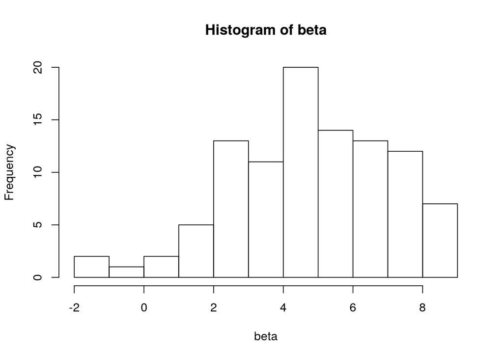

```r
library(Rcpp)
library(RcppGSL)

beta <- my_rnorm(nsamp=100, mu=5, sigma=2, seed=123)
hist(beta)
```

# 3 RcppArmadillo example

Function to center and scale the columns of a numeric matrix : ## C++ code

```cpp
#include <RcppArmadillo.h>
// [[Rcpp::depends(RcppArmadillo)]]

// [[Rcpp::export]]
arma::mat arma_scale(const arma::mat X) {

  // Define dimensions of the matrix
  int n = X.n_rows, k = X.n_cols;

  // Initialize the matrix to store results
  arma::mat X_scaled(n,k);

  // means
  arma::rowvec col_means = arma::mean(X,0);
  // standard deviations
  arma::rowvec col_sd  = arma::stddev(X,0);

  // Scale and center each column of the matrix
  for (int  p= 0; p < k; p++) {
    X_scaled.col(p) = (X.col(p)-col_means(p))/col_sd(p);
  }

  return X_scaled;
}
```

## 3.1 R code

```r
library(Rcpp)
library(RcppArmadillo)

# Center and reduce a matrix
X <- matrix(rnorm(50),ncol=5)
X_scaled <- arma_scale(X)
## Check if the resulting matrix is scaled and centered
colMeans(X_scaled)
```

```
## [1]  1.665335e-17  3.122502e-18  7.285839e-18 -1.318390e-17  1.221245e-16
```

```r
var(X_scaled)
```

```
##            [,1]       [,2]       [,3]       [,4]       [,5]
## [1,]  1.0000000 -0.4073269  0.2761396 -0.5286881 -0.2519599
## [2,] -0.4073269  1.0000000 -0.2446162  0.3904206  0.0415110
## [3,]  0.2761396 -0.2446162  1.0000000 -0.4577359 -0.9223117
## [4,] -0.5286881  0.3904206 -0.4577359  1.0000000  0.3868571
## [5,] -0.2519599  0.0415110 -0.9223117  0.3868571  1.0000000
```

# 4 Distance computation

## 4.1 Mathematical definition

The Euclidean distance between two points whose coordinates are $A=(x_A, y_A)$ and $B=(x_B,y_B)$ is given by
$$\sqrt{(x_B-x_A)^2 + (y_B-y_A)^2}.$$

## 4.2 C++ function

(in file `Code/arma_distmat.cpp`)

```cpp
#include <RcppArmadillo.h>
// [[Rcpp::depends(RcppArmadillo)]]

using namespace Rcpp;
using namespace arma;

// [[Rcpp::export]]


arma::mat arma_distmat(arma::mat X) {

  // Number of points
  int np = X.n_rows;

  // Initialize with zeros the matrix to store results
  arma::mat distmat; distmat.zeros(np, np);

  // Loop on all points
  for (int i = 0; i < np; i++) {
    arma::vec p0 = X.row(i).t(); // fix a point

    // Loop to calculate the distances between this point and the next ones
    for (int j = i + 1; j < np; j++) {
      arma::vec p1 = X.row(j).t();
      arma::vec diff = p0 - p1; // (x0-x1,y0-y1)
      double squared_diff = as_scalar(diff.t() * diff); // (x0-x1)² + (y0-y1)²
      // Fill the distance matrix with the square root of precedent value
      distmat(j, i) = distmat(i, j) = sqrt(squared_diff);
    }
  }
  return distmat;
}
```

## 4.3 R function

```r
R_distmat <- function(X){

  # Number of points
  np <- nrow(X)

  # Initialize with zeros the matrix to store results
  distmat <- matrix(0,nrow=np,ncol=np)

  # Loop on points
  for (i in 1:(np-1)) {
    p0 <- X[i,] # fix a point

    # Loop to calculate the distances between this point and the next ones
    for (j in (i+1):np){
    p1 <- X[j,]
    diff <- p0-p1 # (x0-x1,y0-y1)
    squared_diff <- t(diff)%*% diff # (x0-x1)² + (y0-y1)²

    # Fill the distance matrix with the square root of precedent value
    distmat[j,i] <- distmat[i,j] <- sqrt(squared_diff)
    }
  }
 return(distmat)
}
```

## 4.4 Data simulation

** Simulation of 1000 points dispersed all over the space : **

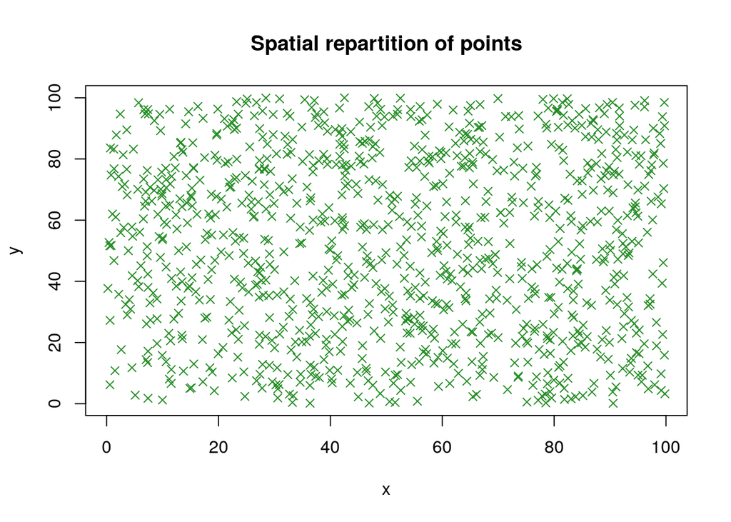

```r
# Data simulation
coords <- matrix(runif(2000,0,100),ncol=2)

# Spatial representation of points
plot(coords[,1],coords[,2],pch=4,xlab="x", ylab="y", main="Spatial repartition of points", col="forestgreen")
```

**Coordinates of 5 points**

| x | y |
| --- | --- |
| 16.0 | 45.6 |
| 19.6 | 87.8 |
| 84.1 | 72.9 |
| 23.2 | 98.7 |
| 48.8 | 82.1 |

```r
library(rdist)

# Call of C++ function
Rcpp::sourceCpp("Code/arma_distmat.cpp")

# Benchmark
library(rbenchmark)
Benchmark <- benchmark(
  "arma_distmat" = {arma_distmat(coords)},
  "cdist" = {cdist(coords,coords)},
  "R_distmat" = {R_distmat(coords)},
  replications=30,
  columns = c("test", "elapsed", "relative"))
```

| test | elapsed | relative |
| --- | --- | --- |
| arma_distmat | 0.5 | 1.0 |
| cdist | 1.4 | 2.8 |
| R_distmat | 55.0 | 109.0 |

## 4.6 Representation of results

**Distance matrix for this points :**

| 0.0 | 42.4 | 73.4 | 53.7 | 49.1 |
| --- | --- | --- | --- | --- |
| 42.4 | 0.0 | 66.2 | 11.5 | 29.8 |
| 73.4 | 66.2 | 0.0 | 66.2 | 36.5 |
| 53.7 | 11.5 | 66.2 | 0.0 | 30.6 |
| 49.1 | 29.8 | 36.5 | 30.6 | 0.0 |

# 5 Simple linear regression

## 5.1 Mathematical definition

We have observations of a response variable available for $n$ individuals $Y=(y_i)_{i=1,\ldots,n}$

and $p$ explanatory variables $(X_1,\ldots,X_p)$ such as $X_1=(X_{11},\ldots,X_{i1},\ldots,X_{n1})'$.

We want to estimate coefficients of the linear regression $\beta=(\beta_0,\beta_1,\ldots,\beta_p)$ such as :
$$y_i = \beta_0 + \beta_1X_{i1}+\ldots+\beta_pX_{ip}+\epsilon_i,$$
where $\epsilon_i \sim \mathcal{N}(0,\sigma^2)$ for $i=1,\ldots,n$.

Then $y_i \sim \mathcal{N}(\beta_0 + \beta_1X_{i1}+\ldots+\beta_pX_{ip}, \ \sigma^2)$.

This gives in matrix writing :

$$Y = X\beta + \epsilon$$
where $X=(\mathbb{1}_n,X_1,\ldots,X_p)$ and $\epsilon=(\epsilon_i)_{i=1,\ldots,n}$.

According to the Ordinary Least Squares (OLS) method, $\beta$ is estimated by :
$$\widehat{\beta}=\left(X'X\right)^{-1}X'y.$$
We define the residuals
$$\widehat{\epsilon} = Y - X\widehat{\beta}=Y-\widehat{Y}.$$
Then residual variance is given by
$$\widehat{\sigma^2}=\dfrac{\sum\limits_{i=1}^n \widehat{\epsilon_i}^2}{n-p-1}.$$
Finally the variance–covariance matrix of coefficients is estimated by
$$V_{\widehat{\beta}}=\widehat{\sigma^2}\left(X'X\right)^{-1}.$$

## 5.2 C++ function

```cpp
#include <RcppArmadillo.h>

// [[Rcpp::depends(RcppArmadillo)]]
// [[Rcpp::export]]

Rcpp::List arma_fastLm(const arma::mat& X, const arma::colvec& y) {
    int n = X.n_rows;
    int p = X.n_cols;

    arma::colvec coef = arma::inv(X.t()*X)*X.t()*y; // fit model y ~ X
    arma::colvec res  = y - X*coef; // residuals

    // std.errors of coefficients
    double s2 = arma::sum(res.t()*res)/(n-p);
    arma::colvec std_err = arma::sqrt(s2*arma::diagvec(arma::inv(X.t()*X)));

    return Rcpp::List::create(Rcpp::Named("coefficients") = coef,
                        Rcpp::Named("stderr") = std_err,
                        Rcpp::Named("residuals")  = res,
                        Rcpp::Named("sigma2")  = s2,
                        Rcpp::Named("df.residual")  = n - p);
}
```

## 5.3 R function

```r
R_fastLm <- function(X, y) {
n <- nrow(X)
p <- ncol(X)

# fit model y ~ X
coef <-solve(t(X) %*% X) %*% t(X) %*% y

# residuals
res <- y - X %*% coef

# std.errors of coefficients
s2 = sum(t(res) %*% res)/(n - p);
std_err = sqrt(s2 %*% diag(solve(t(X)%*%X)))

return(list("coefficients" = coef,
            "stderr" = std_err,
            "residuals" = res,
            "sigma2" = s2,
            "df.residual" = n - p))
}
```

## 5.4 Linear regression on trees data set

This data set provides measurements of the girth, height and volume of timber in 31 felled black cherry trees. Volume will be considered as the variable to be explained and girths and heights as the explanatory variables. To have linear relationship between this variables, we will consider their log.

```r
library(datasets)

# Trees data-set
y <- log(trees$Volume)
X <- cbind(1, log(trees$Girth), log(trees$Height))
```

```r
# Call C++ function
Rcpp::sourceCpp("Code/arma_fastLm.cpp")

# Benchmark
library(rbenchmark)
Benchmark <- benchmark(
  "arma_fastLm" = {arma_fastLm(X,y)},
  "R_fastLm" = {R_fastLm(X,y)},
  replications=100,
  columns = c("test", "elapsed", "relative"))
```

| test | elapsed | relative |
| --- | --- | --- |
| arma_fastLm | 0.002 | 1 |
| R_fastLm | 0.006 | 3 |

## 5.6 Representation of results

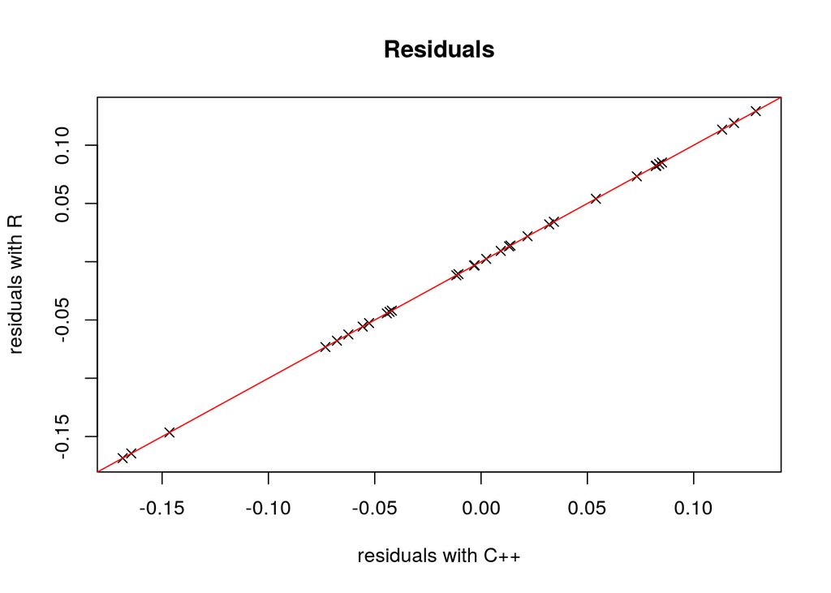

```r
# Trees data-set
y <- log(trees$Volume)
X <- cbind(1, log(trees$Girth), log(trees$Height))

# fit model y ~ X
arma_mod <- arma_fastLm(X,y)
R_mod <- R_fastLm(X,y)

# Comparison of residuals obtained with R and C++ functions
plot(arma_mod$residuals,R_mod$residuals,xlab="residuals with C++",ylab="residuals with R",pch=4, main="Residuals")
abline(a=0,b=1, col="red")
```

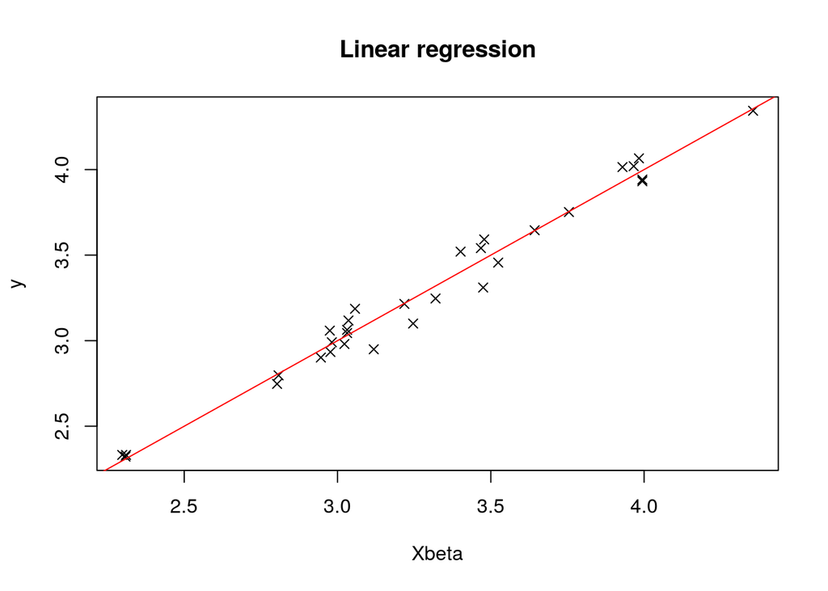

```r
# Representation of the linear regression
plot(X%*%arma_mod$coefficients,y,xlab="Xbeta",ylab="y",pch=4, main ="Linear regression")
abline(a=0,b=1, col="red")
```

# 6 Log-likelihood computation

## 6.1 Mathematical definition

The likelihood function expresses the plausibilities of different parameter values for a given sample of data.
The maximum of this function, if it exists, correspond to the combination of model parameter values that maximize the probability of drawing the sample actually obtained.
The likelihood corresponding to the previous simple linear model is given by :
$$\begin{aligned}
L(\beta,\sigma^2) &= \mathbb{P}(y_i \ | \ \beta, \sigma^2) \\
&=\prod \limits_{i=1}^n \frac{1}{\sigma \sqrt{2\pi}}\exp{\left(-\frac{1}{2\sigma^2}(y_i-\beta_0-X_{i1}\beta_1-\ldots-X_{ip}\beta_p)^2 \right)}
\end{aligned}$$

Then the log-likelihood is :
$$\begin{aligned}
l(\beta,\sigma^2) &= \log{\left(L(\beta,\sigma^2)\right)} \\
&= \sum \limits_{i=1}^n \ \log \left(\frac{1}{\sigma \sqrt{2\pi}}\right) -\frac{1}{2\sigma^2}(y_i-\beta_0-X_{i1}\beta_1-\ldots-X_{ip}\beta_p)^2\\
&= -n\log(\sigma)-n\frac{\log(2\pi)}{2} -\frac{1}{2\sigma^2} \sum \limits_{i=1}^n (y_i-\beta_0-X_{i1}\beta_1-\ldots-X_{ip}\beta_p)^2
\end{aligned}$$

## 6.2 Exercise

1. Implement a function in C++ using RcppArmadillo to compute the log-likelihood corresponding to the previous simple linear model taking as argument the explicative variables $X$, the response variable $Y$, the estimated regression coefficients $\widehat{\beta}$ and the calculated residual variance $\widehat{\sigma^2}$.
2. Use trees data set to fit three distincts linear models with the log of the Volume as response variable and different choices of explanatory variables.
3. Compute the log-likelihood of each model.
4. Deduce from the values obtained which model best reflects the data.